# ising_regen_test

#### read in some test corr functions and determine an intrinsic MSE based on using the MC model

```python
%load_ext autoreload
%autoreload 2
```

```python
import re
import os
import sys
import shutil
from shutil import copyfile, copy2
from shutil import move
```

```python
import numpy as np
import pandas as pd
import matplotlib.pyplot as plt
import matplotlib.pylab as pylab
import seaborn as sns
from scipy import stats
# Cause plots to be displayed in the notebook:
%matplotlib inline
```

```python
import subprocess
```

```python
from matplotlib import cm
from latt2D_modules import calc_diffuse, calc_diffuse_cfs3, calc_diffuse_cfs4
from latt2D_modules import get_occ_map, get_2D_occ_map_from_seq,store_occ_map_as_seq
from latt2D_modules import plot_occ_map,read_bin,output_16bit_pgm
import time
```

```python
from sklearn.metrics import r2_score
from sklearn.metrics import accuracy_score
from sklearn.metrics import mean_squared_error
from sklearn.metrics import mean_absolute_error
```

```python
# read in all the correlation datum  for CFS2 griding
df1=pd.read_csv('output_correlations_1000.csv')
df2=pd.read_csv('output_correlations_2000.csv')
df3=pd.read_csv('output_correlations_3000.csv')
df_corfu=pd.concat([df1,df2,df3],axis=0)
df_corfu=df_corfu.drop('Unnamed: 0',axis=1)
df_corfu.reset_index(inplace=True,drop=True)
```

```python
df_corfu.describe()
```

|  | 00 | 01 | 10 | 11 |
| --- | --- | --- | --- | --- |
| count | 5000.000000 | 5000.000000 | 5000.000000 | 5000.000000 |
| mean | 0.999619 | -0.011148 | -0.007468 | 0.001628 |
| std | 0.000528 | 0.469855 | 0.476303 | 0.475627 |
| min | 0.994465 | -0.921764 | -0.920231 | -0.915264 |
| 25% | 0.999498 | -0.401060 | -0.401672 | -0.403457 |
| 50% | 0.999836 | -0.017684 | -0.014525 | 0.009275 |
| 75% | 0.999959 | 0.371125 | 0.387132 | 0.392816 |
| max | 1.000000 | 0.913594 | 0.927990 | 0.916544 |

```python
# read in all the correlation datum  for CFS3 griding
df_corfu_cfs3=pd.read_csv('output_correlations_cfs3_5000.csv')
df_corfu_cfs3=df_corfu_cfs3.drop('Unnamed: 0',axis=1)
df_corfu_cfs3.reset_index(inplace=True,drop=True)
df_corfu_cfs3.describe()
```

|  | 00 | 01 | 02 | 10 | 11 | 12 | 20 | 21 | 22 |
| --- | --- | --- | --- | --- | --- | --- | --- | --- | --- |
| count | 5000.000000 | 5000.000000 | 5000.000000 | 5000.000000 | 5000.000000 | 5000.000000 | 5000.000000 | 5000.000000 | 5000.000000 |
| mean | 0.999595 | -0.001524 | 0.030086 | 0.003661 | 0.001820 | -0.005355 | 0.035394 | -0.002054 | 0.034959 |
| std | 0.000552 | 0.313728 | 0.397112 | 0.315408 | 0.337084 | 0.380114 | 0.402072 | 0.386541 | 0.363526 |
| min | 0.995267 | -0.879424 | -0.859210 | -0.895424 | -0.839097 | -0.862953 | -0.867137 | -0.882524 | -0.878833 |
| 25% | 0.999462 | -0.244261 | -0.297618 | -0.240006 | -0.269163 | -0.318172 | -0.304072 | -0.312611 | -0.255047 |
| 50% | 0.999815 | -0.000518 | 0.028689 | 0.003190 | 0.006080 | -0.016108 | 0.030357 | -0.011228 | 0.043116 |
| 75% | 0.999959 | 0.239661 | 0.356709 | 0.247908 | 0.270532 | 0.302623 | 0.375400 | 0.324498 | 0.320213 |
| max | 1.000000 | 0.906503 | 0.846394 | 0.870275 | 0.907827 | 0.850767 | 0.872361 | 0.865904 | 0.864945 |

```python
# read in all the correlation datum  for CFS4 griding
df_corfu_cfs4=pd.read_csv('output_correlations_cfs4_5000.csv')
df_corfu_cfs4=df_corfu_cfs4.drop('Unnamed: 0',axis=1)
df_corfu_cfs4.reset_index(inplace=True,drop=True)
df_corfu_cfs4.describe()
```

|  | 00 | 01 | 02 | 03 | 10 | 11 | 12 | 13 | 20 | 21 | 22 | 23 | 30 | 31 | 32 | 33 |
| --- | --- | --- | --- | --- | --- | --- | --- | --- | --- | --- | --- | --- | --- | --- | --- | --- |
| count | 5000.000000 | 5000.000000 | 5000.000000 | 5000.000000 | 5000.000000 | 5000.000000 | 5000.000000 | 5000.000000 | 5000.000000 | 5000.000000 | 5000.000000 | 5000.000000 | 5000.000000 | 5000.000000 | 5000.000000 | 5000.000000 |
| mean | 0.999615 | 0.001224 | 0.013416 | 0.004695 | -0.002513 | 0.000781 | -0.004900 | -0.002588 | 0.015622 | -0.004634 | 0.024057 | 0.000096 | -0.006685 | -0.005733 | 0.004220 | -0.000245 |
| std | 0.000545 | 0.256659 | 0.289073 | 0.339949 | 0.255911 | 0.276429 | 0.295587 | 0.327140 | 0.288942 | 0.291742 | 0.301712 | 0.314419 | 0.339040 | 0.329032 | 0.315226 | 0.301563 |
| min | 0.993853 | -0.763325 | -0.757056 | -0.772841 | -0.797169 | -0.780998 | -0.840339 | -0.769641 | -0.718423 | -0.826340 | -0.827252 | -0.755431 | -0.753807 | -0.790508 | -0.763203 | -0.771482 |
| 25% | 0.999498 | -0.187328 | -0.208502 | -0.274235 | -0.195215 | -0.208425 | -0.235281 | -0.265685 | -0.207778 | -0.228512 | -0.211749 | -0.246443 | -0.283774 | -0.267258 | -0.251281 | -0.232110 |
| 50% | 0.999836 | 0.004515 | 0.015746 | 0.009579 | -0.000213 | 0.001466 | -0.008188 | -0.009795 | 0.013938 | -0.003211 | 0.028741 | -0.003223 | -0.003555 | -0.006739 | 0.001586 | 0.002956 |
| 75% | 0.999959 | 0.188684 | 0.232081 | 0.282336 | 0.185581 | 0.212943 | 0.228630 | 0.263630 | 0.239518 | 0.222379 | 0.265429 | 0.246362 | 0.265493 | 0.257337 | 0.260744 | 0.236522 |
| max | 1.000000 | 0.803056 | 0.771075 | 0.780769 | 0.761024 | 0.795136 | 0.772769 | 0.768304 | 0.777369 | 0.774256 | 0.812800 | 0.772800 | 0.766144 | 0.766348 | 0.759892 | 0.751744 |

```python
# read in all the correlation datum  for CFS4 griding
df_corfu_cfs4_big=pd.read_csv('output_correlations_cfs4_big_5000.csv')
df_corfu_cfs4_big=df_corfu_cfs4_big.drop('Unnamed: 0',axis=1)
df_corfu_cfs4_big.reset_index(inplace=True,drop=True)
df_corfu_cfs4_big.describe()
```

|  | 00 | 01 | 02 | 03 | 10 | 11 | 12 | 13 | 20 | 21 | 22 | 23 | 30 | 31 | 32 | 33 |
| --- | --- | --- | --- | --- | --- | --- | --- | --- | --- | --- | --- | --- | --- | --- | --- | --- |
| count | 5000.000000 | 5000.000000 | 5000.000000 | 5000.000000 | 5000.000000 | 5000.000000 | 5000.000000 | 5000.000000 | 5000.000000 | 5000.000000 | 5000.000000 | 5000.000000 | 5000.000000 | 5000.000000 | 5000.000000 | 5000.000000 |
| mean | 0.999891 | 0.004946 | 0.012484 | 0.001425 | 0.004712 | 0.007505 | -0.004842 | 0.000767 | 0.023760 | -0.005177 | 0.018360 | 0.001835 | -0.006725 | 0.002540 | -0.000443 | 0.009603 |
| std | 0.000154 | 0.254295 | 0.293658 | 0.338722 | 0.256082 | 0.269184 | 0.288865 | 0.325434 | 0.292073 | 0.298116 | 0.301633 | 0.311789 | 0.345432 | 0.326947 | 0.312520 | 0.303450 |
| min | 0.998702 | -0.759754 | -0.733507 | -0.766066 | -0.762588 | -0.772244 | -0.818260 | -0.795656 | -0.785648 | -0.795576 | -0.730039 | -0.743131 | -0.800899 | -0.791766 | -0.787836 | -0.751304 |
| 25% | 0.999858 | -0.186765 | -0.210973 | -0.275793 | -0.183321 | -0.199189 | -0.226696 | -0.259579 | -0.198752 | -0.237934 | -0.222335 | -0.252029 | -0.287547 | -0.264763 | -0.244908 | -0.233233 |
| 50% | 0.999949 | 0.009490 | 0.007923 | 0.009292 | 0.001884 | 0.005712 | -0.007321 | 0.004972 | 0.027776 | -0.010679 | 0.028775 | 0.007744 | -0.016932 | -0.000269 | -0.006122 | 0.011245 |
| 75% | 0.999988 | 0.196134 | 0.237760 | 0.282020 | 0.195265 | 0.209314 | 0.222980 | 0.266406 | 0.254085 | 0.230358 | 0.248921 | 0.243817 | 0.276468 | 0.266467 | 0.252579 | 0.255392 |
| max | 1.000000 | 0.789808 | 0.762998 | 0.760733 | 0.785265 | 0.870522 | 0.792439 | 0.776439 | 0.766461 | 0.777772 | 0.853416 | 0.783755 | 0.778503 | 0.798040 | 0.774717 | 0.792878 |

```python
# helper functions
def plot_selected_image_from_cfs2(k,ls=12):
    fig, axes = plt.subplots(1, 2, figsize=(10,6))
    occ2d=get_2D_occ_map_from_seq('./image_inputs_seq/ising2D_seq_%s.dat'%(str(k).zfill(6)))
    axes[0].imshow(np.transpose(occ2d),interpolation='nearest',cmap='gray')
    axes[0].set_xlabel('a-axis',size=ls)
    axes[0].set_ylabel('b-axis',size=ls)
    imdat = read_bin('./image_inputs_bin/hk0_%s.bin'%str(k).zfill(6), npixels=64, offset=1280)
    axes[1].imshow(np.flip(imdat,0),cmap='gray')
    axes[1].set_xlabel('h-axis',size=ls)
    axes[1].set_ylabel('k-axis',size=ls)

def plot_selected_image_from_cfs3(k,ls=12):
    fig, axes = plt.subplots(1, 2, figsize=(10,6))
    occ2d=get_2D_occ_map_from_seq('./cfs3_image_inputs_seq/ising2D_seq_%s.dat'%(str(k).zfill(6)))
    axes[0].imshow(np.transpose(occ2d),interpolation='nearest',cmap='gray')
    axes[0].set_xlabel('a-axis',size=ls)
    axes[0].set_ylabel('b-axis',size=ls)
    imdat = read_bin('./cfs3_image_inputs_bin/hk0_%s.bin'%str(k).zfill(6), npixels=64, offset=1280)
    axes[1].imshow(np.flip(imdat,0),cmap='gray')
    axes[1].set_xlabel('h-axis',size=ls)
    axes[1].set_ylabel('k-axis',size=ls)

def plot_selected_image_from_cfs4(k,ls=12):
    fig, axes = plt.subplots(1, 2, figsize=(10,6))
    occ2d=get_2D_occ_map_from_seq('./cfs4_image_inputs_seq/ising2D_seq_%s.dat'%(str(k).zfill(6)))
    axes[0].imshow(np.transpose(occ2d),interpolation='nearest',cmap='gray')
    axes[0].set_xlabel('a-axis',size=ls)
    axes[0].set_ylabel('b-axis',size=ls)
    imdat = read_bin('./cfs4_image_inputs_bin/hk0_%s.bin'%str(k).zfill(6), npixels=64, offset=1280)
    axes[1].imshow(np.flip(imdat,0),cmap='gray')
    axes[1].set_xlabel('h-axis',size=ls)
    axes[1].set_ylabel('k-axis',size=ls)

def plot_selected_image_from_cfs4_big(k,ls=12):
    fig, axes = plt.subplots(1, 2, figsize=(10,6))
    occ2d=get_2D_occ_map_from_seq('./cfs4_big_image_inputs_seq/ising2D_seq_%s.dat'%(str(k).zfill(6)))
    axes[0].imshow(np.transpose(occ2d),interpolation='nearest',cmap='gray')
    axes[0].set_xlabel('a-axis',size=ls)
    axes[0].set_ylabel('b-axis',size=ls)
    imdat = read_bin('./cfs4_big_image_inputs_bin/hk0_%s.bin'%str(k).zfill(6), npixels=64, offset=1280)
    axes[1].imshow(np.flip(imdat,0),cmap='gray')
    axes[1].set_xlabel('h-axis',size=ls)
    axes[1].set_ylabel('k-axis',size=ls)

def plot_from_exp1(ls=12):
    fig, axes = plt.subplots(1, 2, figsize=(10,6))
    occ3D=get_occ_map('./expfiles_1/ising2D_occ.txt')
    axes[0].imshow(np.transpose(occ3D[:,:,0]),interpolation='nearest',cmap='gray')
    axes[0].set_xlabel('a-axis',size=ls)
    axes[0].set_ylabel('b-axis',size=ls)
    imdat = read_bin('./expfiles_1/hk0.bin', npixels=64, offset=1280)
    axes[1].imshow(np.flip(imdat,0),cmap='gray')
    axes[1].set_xlabel('h-axis',size=ls)
    axes[1].set_ylabel('k-axis',size=ls)
    corr_out=np.loadtxt('expfiles_1/corr.out')
    return  corr_out
```

```python
def plot_corfunc(df,cfs=2):
    corrf=df.values.reshape((cfs,-1))
    sns.heatmap(corrf, cmap='bwr',square=True, annot=True,annot_kws={"fontsize":20},vmax=1.0,vmin=-1.0 ,cbar_kws={'shrink':0.85}  )
```

```python
def get_metrics_compare_regen_images(k_test,exp=1):
    corr_out_0=df_corfu.iloc[k_test].values
    corr_out_1=np.loadtxt('expfiles_%d/corr.out'%exp)
    imdat_0 = read_bin('./image_inputs_bin/hk0_%s.bin'%str(k_test).zfill(6), npixels=64, offset=1280)
    imdat_1 = read_bin('./expfiles_%d/hk0.bin'%exp, npixels=64, offset=1280)

    r2c = r2_score(corr_out_0.flatten(), corr_out_1.flatten())
    msec=mean_squared_error(corr_out_0,corr_out_1.flatten())
    maec=mean_absolute_error(corr_out_0,corr_out_1.flatten())

    r2i=r2_score(imdat_0.flatten(),imdat_1.flatten())
    msei=mean_squared_error(imdat_0.flatten(),imdat_1.flatten())
    maei=mean_absolute_error(imdat_0.flatten(),imdat_1.flatten())
    return [r2c,msec,maec,r2i,msei,maei]

def get_metrics_compare_regen_images_cfs3(k_test,corr_out_0,exp=1):

    corr_out_1=np.loadtxt('expfiles_%d/corr.out'%exp)
    imdat_0 = read_bin('./cfs3_image_inputs_bin/hk0_%s.bin'%str(k_test).zfill(6), npixels=64, offset=1280)
    imdat_1 = read_bin('./expfiles_%d/hk0.bin'%exp, npixels=64, offset=1280)

    r2c = r2_score(corr_out_0.flatten(), corr_out_1.flatten())
    msec=mean_squared_error(corr_out_0,corr_out_1.flatten())
    maec=mean_absolute_error(corr_out_0,corr_out_1.flatten())

    r2i=r2_score(imdat_0.flatten(),imdat_1.flatten())
    msei=mean_squared_error(imdat_0.flatten(),imdat_1.flatten())
    maei=mean_absolute_error(imdat_0.flatten(),imdat_1.flatten())
    return [r2c,msec,maec,r2i,msei,maei]

def get_metrics_compare_regen_images_cfs4(k_test,corr_out_0,exp=1):

    corr_out_1=np.loadtxt('expfiles_%d/corr.out'%exp)
    imdat_0 = read_bin('./cfs4_image_inputs_bin/hk0_%s.bin'%str(k_test).zfill(6), npixels=64, offset=1280)
    imdat_1 = read_bin('./expfiles_%d/hk0.bin'%exp, npixels=64, offset=1280)

    r2c = r2_score(corr_out_0.flatten(), corr_out_1.flatten())
    msec=mean_squared_error(corr_out_0,corr_out_1.flatten())
    maec=mean_absolute_error(corr_out_0,corr_out_1.flatten())

    r2i=r2_score(imdat_0.flatten(),imdat_1.flatten())
    msei=mean_squared_error(imdat_0.flatten(),imdat_1.flatten())
    maei=mean_absolute_error(imdat_0.flatten(),imdat_1.flatten())
    return [r2c,msec,maec,r2i,msei,maei]
```

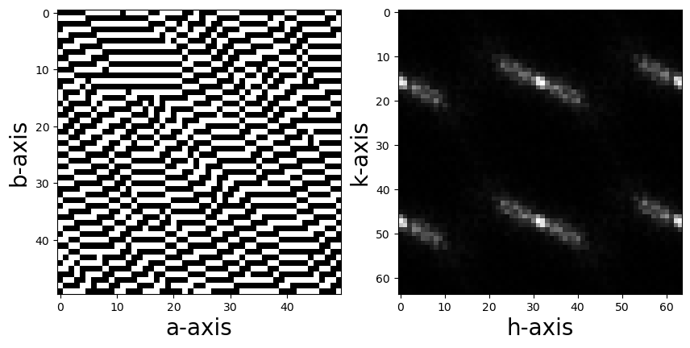

```python
#
# k=np.random.randint(0,5000,1)[0] # grab a random image from the 5000
# print(k)
k=0
plot_selected_image_from_cfs2(k,ls=20)
# print(df_corfu.iloc[k])
```

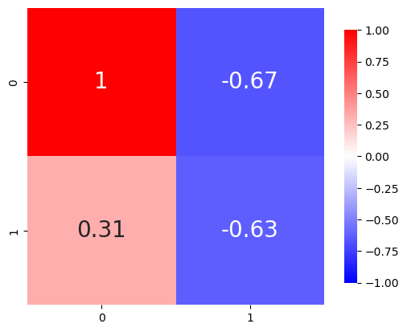

```python
plot_corfunc(df_corfu.iloc[k],cfs=2)
```

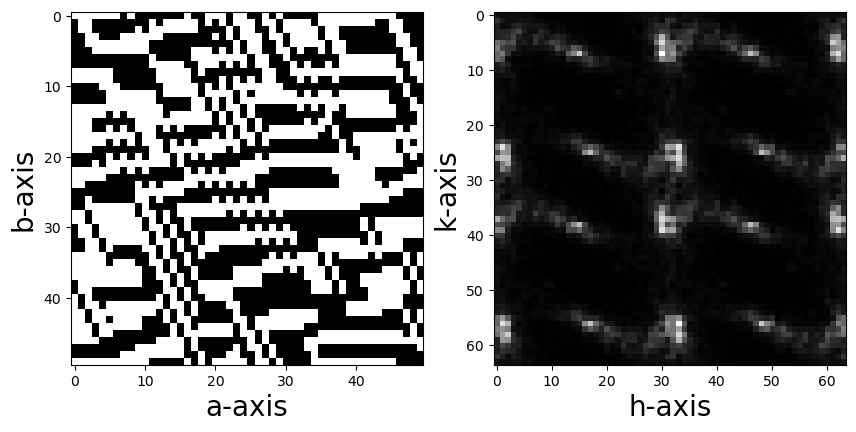

```python
k=0
plot_selected_image_from_cfs3(k,ls=20)
```

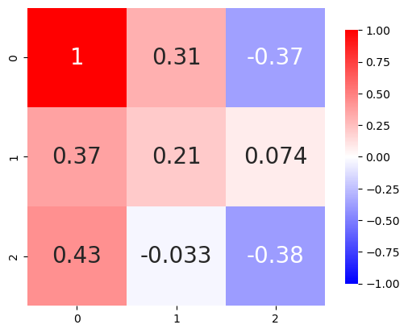

```python
plot_corfunc(df_corfu_cfs3.iloc[k],cfs=3)
```

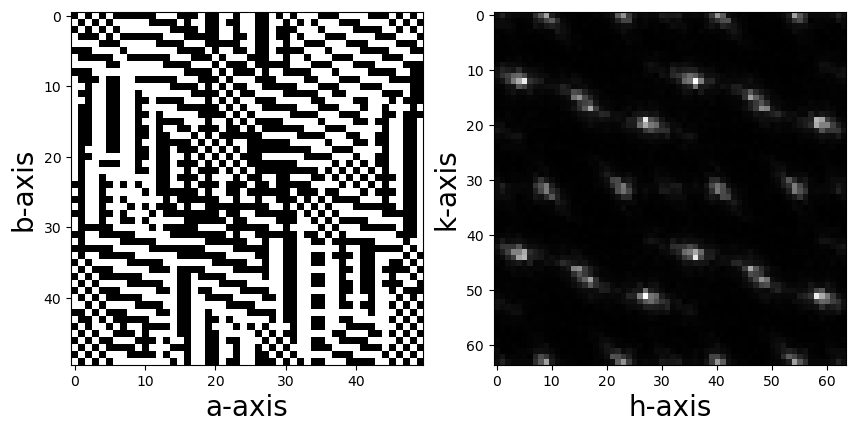

```python
plot_selected_image_from_cfs4(k,ls=20)
```

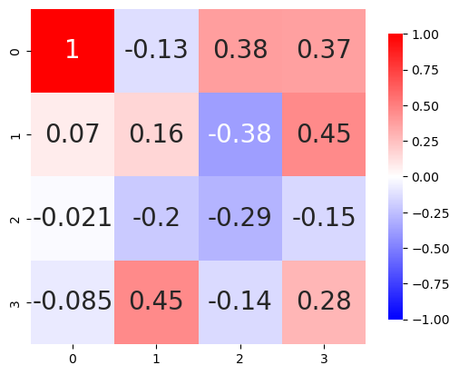

```python
plot_corfunc(df_corfu_cfs4.iloc[k],cfs=4)
```

```python
corrin=df_corfu.iloc[k].values
fhout=open('corr.in','w')
fhout.write("%.6f %.6f\n%.6f %.6f\n"%(corrin[0],corrin[1],corrin[2],corrin[3]))
fhout.close()
```

```python
calc_diffuse(iconc,1,icycles,ianneal,1)
```

```python
corr_out=plot_from_exp1()
corr_out.flatten()
```

[output not shown]

```python
my_metrics=get_metrics_compare_regen_images(k)

my_metrics
```

[output not shown]

#### these are basic parameters for running swap-MC for the CFS2 mode

```python
iconc=0.50 # spin concentration
cread=0    # reading correlation function from input file  otherwise it will be generated randomly
'corr.in'
'jswitch.in'
icycles=200  # MC cycles
ianneal=200  # MC input


corrin=np.array([[1.000000,  0.000000],
                 [0.00000,  0.000000]])

fhout=open('corr.in','w')
fhout.write("%.6f %.6f\n%.6f %.6f\n"%(corrin[0,0],corrin[0,1],corrin[1,0],corrin[1,1]))
fhout.close()

jsw=np.array([[1, 1],
             [1, 1]])

fhout=open('jswitch.in','w')
fhout.write("%d %d\n%d %d\n"%(jsw[0,0],jsw[0,1],jsw[1,0],jsw[1,1]))
fhout.close()
```

### select 1000 correlation function state vectors at random and calcualte the GOF metrics

### for swap-MC regeneration of the state vector and the corresponding FT

### Do this for CFS2 CFS3 and CFS4 parameter generation. compare histograms of the errors using KDE

```python
iconc=0.50 # spin concentration
cread=0    # reading correlation function from input file  otherwise it will be generated randomly
icycles=200  # MC cycles
ianneal=200  # MC input

df_metrics=pd.DataFrame(columns=['r2_c','mse_c','mae_c','r2_i','mse_i','mae_i'])

for t in range(1000):
    k=np.random.randint(0,5000,1)[0] # grab a random image from the 5000
    corrin=df_corfu.iloc[k].values
    fhout=open('corr.in','w')
    fhout.write("%.6f %.6f\n%.6f %.6f\n"%(corrin[0],corrin[1],corrin[2],corrin[3]))
    fhout.close()
    calc_diffuse(iconc,1,icycles,ianneal,1) # do the regen on the image
    df_metrics.loc[t]=get_metrics_compare_regen_images(k)
```

```python
df_metrics.describe()
```

|  | r2_c | mse_c | mae_c | r2_i | mse_i | mae_i |
| --- | --- | --- | --- | --- | --- | --- |
| count | 1000.000000 | 1000.000000 | 1000.000000 | 1000.000000 | 1000.000000 | 1000.000000 |
| mean | 0.998620 | 0.000232 | 0.010299 | 0.575500 | 0.140021 | 0.119456 |
| std | 0.005136 | 0.000285 | 0.006057 | 0.195479 | 0.130911 | 0.011697 |
| min | 0.902308 | 0.000002 | 0.000803 | -0.579130 | 0.022547 | 0.081005 |
| 25% | 0.998856 | 0.000057 | 0.006010 | 0.498459 | 0.072451 | 0.112157 |
| 50% | 0.999524 | 0.000134 | 0.008845 | 0.619858 | 0.106709 | 0.118541 |
| 75% | 0.999809 | 0.000285 | 0.013200 | 0.701552 | 0.158587 | 0.125467 |
| max | 0.999996 | 0.002604 | 0.039636 | 0.946180 | 1.147219 | 0.174708 |

```python
df_metrics.to_csv('regen_metrics_cs2.csv')
```

```python
iconc=0.50 # spin concentration
cread=0    # reading correlation function from input file  otherwise it will be generated randomly
icycles=200  # MC cycles
ianneal=200  # MC input

df_metrics_cfs3=pd.DataFrame(columns=['r2_c','mse_c','mae_c','r2_i','mse_i','mae_i'])

for t in range(1000):
    k=np.random.randint(0,5000,1)[0] # grab a random image from the 5000
    corrin=df_corfu_cfs3.iloc[k].values
    fhout=open('corr.in','w')
    fhout.write("%.6f %.6f %.6f\n%.6f %.6f %.6f\n%.6f %.6f %.6f\n"%(tuple(corrin.flatten())))
    fhout.close()
    calc_diffuse_cfs3(iconc,1,icycles,ianneal,1) # do the regen on the image
    df_metrics_cfs3.loc[t]=get_metrics_compare_regen_images_cfs3(k,corrin)
```

```python
df_metrics_cfs3.to_csv('regen_metrics_cfs3.csv')
df_metrics_cfs3.head()
```

|  | r2_c | mse_c | mae_c | r2_i | mse_i | mae_i |
| --- | --- | --- | --- | --- | --- | --- |
| 0 | 0.999792 | 0.000048 | 0.005723 | 0.868685 | 0.071819 | 0.096689 |
| 1 | 0.993157 | 0.000539 | 0.018862 | 0.577352 | 0.077156 | 0.118850 |
| 2 | 0.999662 | 0.000056 | 0.006447 | 0.462761 | 0.087680 | 0.124752 |
| 3 | 0.998844 | 0.000208 | 0.011734 | 0.452269 | 0.132856 | 0.122487 |
| 4 | 0.999492 | 0.000103 | 0.008789 | 0.550464 | 0.109030 | 0.130901 |

```python
iconc=0.50 # spin concentration
cread=0    # reading correlation function from input file  otherwise it will be generated randomly
icycles=300  # MC cycles
ianneal=300  # MC input

df_metrics_cfs4=pd.DataFrame(columns=['r2_c','mse_c','mae_c','r2_i','mse_i','mae_i'])

for t in range(1000):
    k=np.random.randint(0,5000,1)[0] # grab a random image from the 5000
    corrin=df_corfu_cfs4.iloc[k].values
    fhout=open('corr.in','w')
    fhout.write("%.6f %.6f %.6f %.6f\n%.6f %.6f %.6f %.6f\n%.6f %.6f %.6f %.6f\n%.6f %.6f %.6f %.6f\n"%(tuple(corrin.flatten())))
    fhout.close()
    calc_diffuse_cfs4(iconc,1,icycles,ianneal,1) # do the regen on the image
    df_metrics_cfs4.loc[t]=get_metrics_compare_regen_images_cfs4(k,corrin)
```

```python
#df_metrics_cfs4.to_csv('regen_metrics_cfs4.csv')
df_metrics_cfs4.describe()
```

|  | r2_c | mse_c | mae_c | r2_i | mse_i | mae_i |
| --- | --- | --- | --- | --- | --- | --- |
| count | 1000.000000 | 1000.000000 | 1000.000000 | 1000.000000 | 1000.000000 | 1000.000000 |
| mean | 0.998680 | 0.000176 | 0.009439 | 0.560471 | 0.167191 | 0.121729 |
| std | 0.002599 | 0.000468 | 0.004962 | 0.245160 | 0.113352 | 0.014032 |
| min | 0.928371 | 0.000014 | 0.002711 | -1.481295 | 0.037417 | 0.082284 |
| 25% | 0.998472 | 0.000070 | 0.006565 | 0.453696 | 0.101437 | 0.112689 |
| 50% | 0.999132 | 0.000113 | 0.008486 | 0.611818 | 0.136019 | 0.120670 |
| 75% | 0.999516 | 0.000192 | 0.010997 | 0.717961 | 0.192997 | 0.130327 |
| max | 0.999919 | 0.013512 | 0.091849 | 0.913122 | 1.459778 | 0.179457 |

```python
df_metrics['gen_mode']=['cfs2' for i in range(1000)]
```

```python
df_metrics_cfs3['gen_mode']=['cfs3' for i in range(1000)]
df_metrics_cfs4['gen_mode']=['cfs4' for i in range(1000)]
```

```python
df_metrics_all=pd.concat([df_metrics,df_metrics_cfs3,df_metrics_cfs4],axis=0)
```

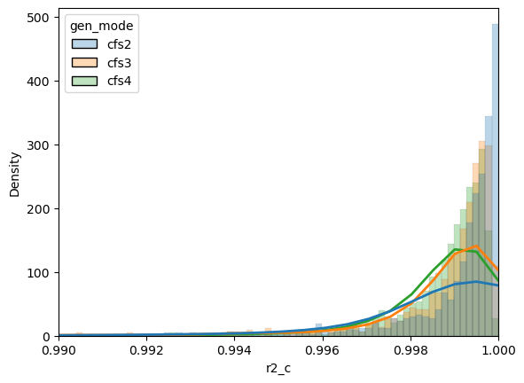

```python
ax=sns.histplot(data=df_metrics_all,x='r2_c',hue='gen_mode',alpha=0.3,kde=True,stat='density',line_kws={'linewidth':2,'alpha':1.0})
ax=plt.xlim([0.99,1.0])
```

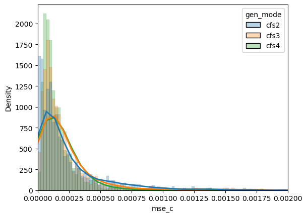

```python
sns.histplot(data=df_metrics_all,x='mse_c',hue='gen_mode',alpha=0.3,kde=True,stat='density',line_kws={'linewidth':2,'alpha':1.0})
ax=plt.xlim([0.0,0.002])
```

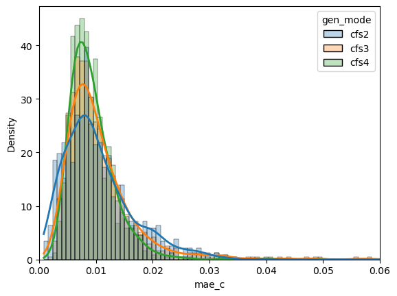

```python
sns.histplot(data=df_metrics_all,x='mae_c',hue='gen_mode',alpha=0.3,kde=True,stat='density',line_kws={'linewidth':2,'alpha':1.0})
ax=plt.xlim([0.0,0.06])
```

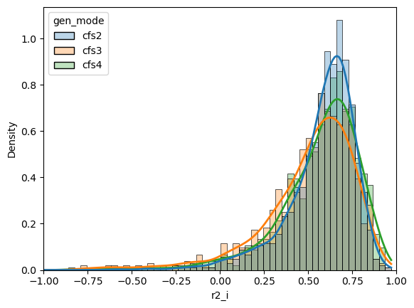

```python
sns.histplot(data=df_metrics_all,x='r2_i',hue='gen_mode',alpha=0.3,kde=True,stat='density',line_kws={'linewidth':2,'alpha':1.0})
ax=plt.xlim([-1.0,1.00])
```

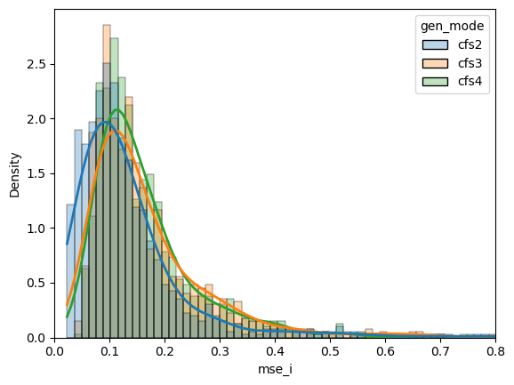

```python
sns.histplot(data=df_metrics_all,x='mse_i',hue='gen_mode',alpha=0.3,kde=True,stat='density',line_kws={'linewidth':2,'alpha':1.0})
ax=plt.xlim([0.0,0.8])
```

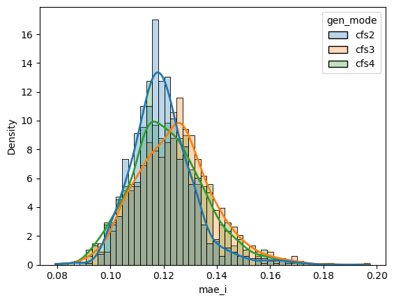

```python
sns.histplot(data=df_metrics_all,x='mae_i',hue='gen_mode',alpha=0.3,kde=True,stat='density',line_kws={'linewidth':2,'alpha':1.0})
```

## example of intensity histogram for CFS4 image

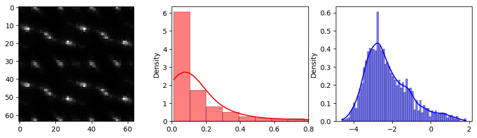

```python
k=0
imdat = read_bin('./cfs4_image_inputs_bin/hk0_%s.bin'%str(k).zfill(6), npixels=64, offset=1280)
fig, ax = plt.subplots(1, 3, figsize=(12,3))
ax[0].imshow(np.flip(imdat,0),cmap='gray')
sns.histplot(data=imdat.flatten(),ax=ax[1],color='r', bins=64,kde=True,stat='density')
ax[1].set_xlim([0.0,0.8])
sns.histplot(data=np.log(imdat.flatten()),ax=ax[2],color='b', bins=64,kde=True,stat='density')
# ax[2].set_xlim([0.0,2.0])
```

## example of intensity histogram for CFS3 image

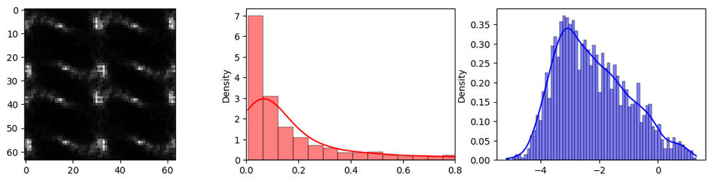

```python
k=0
imdat = read_bin('./cfs3_image_inputs_bin/hk0_%s.bin'%str(k).zfill(6), npixels=64, offset=1280)
fig, ax = plt.subplots(1, 3, figsize=(14,3))
ax[0].imshow(np.flip(imdat,0),cmap='gray')
sns.histplot(data=imdat.flatten(),ax=ax[1],color='r', bins=64,kde=True,stat='density')
ax[1].set_xlim([0.0,0.8])
sns.histplot(data=np.log(imdat.flatten()),ax=ax[2],color='b', bins=64,kde=True,stat='density')
# ax[2].set_xlim([0.0,2.0])
```

## example of intensity histogram for CFS2 image

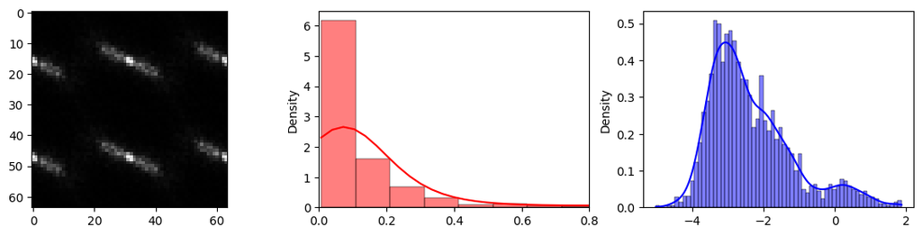

```python
k=0
imdat = read_bin('./image_inputs_bin/hk0_%s.bin'%str(k).zfill(6), npixels=64, offset=1280)
fig, ax = plt.subplots(1, 3, figsize=(14,3))
ax[0].imshow(np.flip(imdat,0),cmap='gray')
sns.histplot(data=imdat.flatten(),ax=ax[1],color='r', bins=64,kde=True,stat='density')
ax[1].set_xlim([0.0,0.8])
sns.histplot(data=np.log(imdat.flatten()),ax=ax[2],color='b', bins=64,kde=True,stat='density')
# ax[2].set_xlim([0.0,2.0])
```

# visual comparision for CFS2

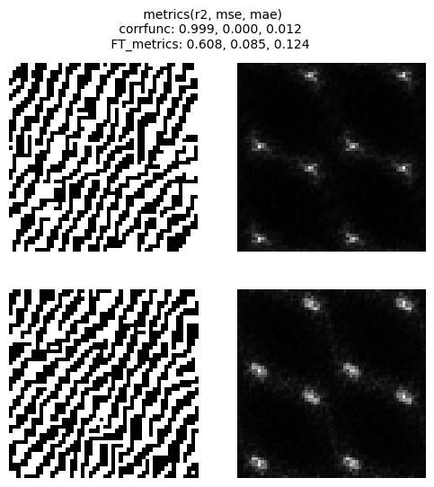

```python
from matplotlib.animation import FuncAnimation
from IPython.display import HTML


# Create a figure and axis for the plot
rows,cols =2,2
fig, axes = plt.subplots(rows, cols, figsize=(6,6))

# Define a function to update the plot
def update_plot(i):
    k=np.random.randint(0,5000,1)[0] # grab a random image from the 5000
    # Update the data for the plot

    # plt.title(get_metrics_compare_regen_images(k))
    occ2d=get_2D_occ_map_from_seq('./image_inputs_seq/ising2D_seq_%s.dat'%str(k).zfill(6))
    axes[0,0].imshow(np.transpose(occ2d),interpolation='nearest',cmap='gray')
    axes[0,0].axis("off")
    imdat = read_bin('./image_inputs_bin/hk0_%s.bin'%str(k).zfill(6), npixels=64, offset=1280)
    axes[0,1].imshow(np.flip(imdat,0),cmap='gray')
    axes[0,1].axis("off")

    corrin=df_corfu.iloc[k].values
    fhout=open('corr.in','w')
    fhout.write("%.6f %.6f\n%.6f %.6f\n"%(corrin[0],corrin[1],corrin[2],corrin[3]))
    fhout.close()
    calc_diffuse(iconc,1,icycles,ianneal,1) # do the regen on the image

    occ3D=get_occ_map('./expfiles_1/ising2D_occ.txt')
    axes[1,0].imshow(np.transpose(occ3D[:,:,0]),interpolation='nearest',cmap='gray')
    axes[1,0].axis("off")
    imdat = read_bin('./expfiles_1/hk0.bin', npixels=64, offset=1280)
    axes[1,1].imshow(np.flip(imdat,0),cmap='gray')
    axes[1,1].axis("off")

    my_metrics=get_metrics_compare_regen_images(k)
    fig.suptitle(" metrics(r2, mse, mae)\n corrfunc: %.3f, %.3f, %.3f \n FT_metrics: %.3f, %.3f, %.3f " %(tuple(my_metrics)), fontsize=10)




 #   df_metrics.loc[t]=get_metrics_compare_regen_images(k)


# update_plot(1)
# Create an animation object
ani = FuncAnimation(fig, update_plot, frames=10, interval=200)

# Display the animation in the notebook

# HTML(ani.to_jshtml())
```

```python
HTML(ani.to_jshtml())
```

```python
from matplotlib import animation
f = './MC_regen_error_cfs2.gif'
writergif = animation.PillowWriter(fps=1)
ani.save(f, writer=writergif)
```

# Visual comparsion for CFS3

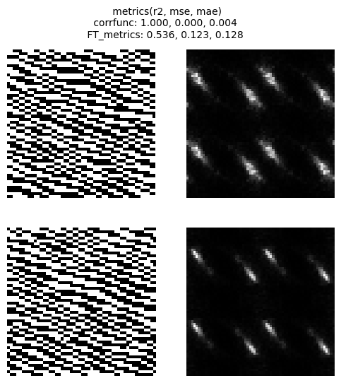

```python
from matplotlib.animation import FuncAnimation
from IPython.display import HTML


# Create a figure and axis for the plot
rows,cols =2,2
fig, axes = plt.subplots(rows, cols, figsize=(6,6))

# Define a function to update the plot
def update_plot_cfs3(i):
    k=np.random.randint(0,5000,1)[0] # grab a random image from the 5000
    # Update the data for the plot

    # plt.title(get_metrics_compare_regen_images(k))
    occ2d=get_2D_occ_map_from_seq('./cfs3_image_inputs_seq/ising2D_seq_%s.dat'%str(k).zfill(6))
    axes[0,0].imshow(np.transpose(occ2d),interpolation='nearest',cmap='gray')
    axes[0,0].axis("off")
    imdat = read_bin('./cfs3_image_inputs_bin/hk0_%s.bin'%str(k).zfill(6), npixels=64, offset=1280)
    axes[0,1].imshow(np.flip(imdat,0),cmap='gray')
    axes[0,1].axis("off")

    corrin=df_corfu_cfs3.iloc[k].values
    fhout=open('corr.in','w')
    fhout.write("%.6f %.6f %.6f\n%.6f %.6f %.6f\n%.6f %.6f %.6f\n"%(tuple(corrin.flatten())))
    fhout.close()
    calc_diffuse_cfs3(iconc,1,icycles,ianneal,1) # do the regen on the image

    occ3D=get_occ_map('./expfiles_1/ising2D_occ.txt')
    axes[1,0].imshow(np.transpose(occ3D[:,:,0]),interpolation='nearest',cmap='gray')
    axes[1,0].axis("off")
    imdat = read_bin('./expfiles_1/hk0.bin', npixels=64, offset=1280)
    axes[1,1].imshow(np.flip(imdat,0),cmap='gray')
    axes[1,1].axis("off")

    my_metrics=get_metrics_compare_regen_images_cfs3(k,corrin)
    fig.suptitle(" metrics(r2, mse, mae)\n corrfunc: %.3f, %.3f, %.3f \n FT_metrics: %.3f, %.3f, %.3f " %(tuple(my_metrics)), fontsize=10)




 #   df_metrics.loc[t]=get_metrics_compare_regen_images(k)


# update_plot(1)
# Create an animation object
ani = FuncAnimation(fig, update_plot_cfs3, frames=10, interval=200)

# Display the animation in the notebook

# HTML(ani.to_jshtml())
```

```python
from matplotlib import animation
f = './MC_regen_error_cfs3.gif'
writergif = animation.PillowWriter(fps=1)
ani.save(f, writer=writergif)
```

# Visual comparsion for CFS4

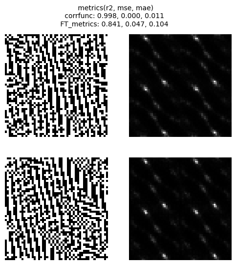

```python
from matplotlib.animation import FuncAnimation
from IPython.display import HTML


# Create a figure and axis for the plot
rows,cols =2,2
fig, axes = plt.subplots(rows, cols, figsize=(6,6))

# Define a function to update the plot
def update_plot_cfs4(i):
    k=np.random.randint(0,5000,1)[0] # grab a random image from the 5000
    # Update the data for the plot

    # plt.title(get_metrics_compare_regen_images(k))
    occ2d=get_2D_occ_map_from_seq('./cfs4_image_inputs_seq/ising2D_seq_%s.dat'%str(k).zfill(6))
    axes[0,0].imshow(np.transpose(occ2d),interpolation='nearest',cmap='gray')
    axes[0,0].axis("off")
    imdat = read_bin('./cfs4_image_inputs_bin/hk0_%s.bin'%str(k).zfill(6), npixels=64, offset=1280)
    axes[0,1].imshow(np.flip(imdat,0),cmap='gray')
    axes[0,1].axis("off")

    corrin=df_corfu_cfs4.iloc[k].values
    fhout=open('corr.in','w')
    fhout.write("%.6f %.6f %.6f %.6f\n%.6f %.6f %.6f %.6f\n%.6f %.6f %.6f %.6f\n%.6f %.6f %.6f %.6f\n"%(tuple(corrin.flatten())))
    fhout.close()
    calc_diffuse_cfs4(iconc,1,icycles,ianneal,1) # do the regen on the image

    occ3D=get_occ_map('./expfiles_1/ising2D_occ.txt')
    axes[1,0].imshow(np.transpose(occ3D[:,:,0]),interpolation='nearest',cmap='gray')
    axes[1,0].axis("off")
    imdat = read_bin('./expfiles_1/hk0.bin', npixels=64, offset=1280)
    axes[1,1].imshow(np.flip(imdat,0),cmap='gray')
    axes[1,1].axis("off")

    my_metrics=get_metrics_compare_regen_images_cfs4(k,corrin)
    fig.suptitle(" metrics(r2, mse, mae)\n corrfunc: %.3f, %.3f, %.3f \n FT_metrics: %.3f, %.3f, %.3f " %(tuple(my_metrics)), fontsize=10)




 #   df_metrics.loc[t]=get_metrics_compare_regen_images(k)


# update_plot(1)
# Create an animation object
ani = FuncAnimation(fig, update_plot_cfs4, frames=10, interval=200)

# Display the animation in the notebook

# HTML(ani.to_jshtml())
```

```python
from matplotlib import animation
f = './MC_regen_error_cfs4.gif'
writergif = animation.PillowWriter(fps=1)
ani.save(f, writer=writergif)
```

## not going to do too much EDA on the theoretically generated data but can do it for the presentation

better to do this in a seperate notebook

#### this is a better way to see the data - for a proper lognormal distribution log(X) ~ N where N is a normal distribution

One common distribution that is used to model scattering intensities is the log-normal distribution, which arises from the random nature of the particle sizes and shapes and the physical processes that lead to scattering. In this case, taking the logarithm of the scattering intensities can result in a normal distribution, which is easier to work with mathematically.

However, other distributions can also be used to model scattering intensities, including the Weibull distribution and other distributions that can account for skewness or heavy tails in the data. The Weibull distribution, in particular, is commonly used to model failure times in materials science, but it can also be used to model scattering intensities in some cases.

In summary, while the log-normal distribution is commonly used to model scattering intensities, other distributions such as the Weibull distribution may be more appropriate in certain cases. The choice of distribution should be based on the specific properties of the sample, the type of scattering, and the instrument used for the measurement, as well as the assumptions and limitations of the particular modeling approach.

## The important thing is that the observed dat must be treated so that it follows a similar distribution

```python
# Fit the data to the model function using curve_fit
popt, pcov = curve_fit(exponential, newbcent,newloghist)
# Plot the data and the fitted curve
x = np.linspace(0, 35, 50)
ax=sns.scatterplot(x=newbcent,y=newloghist,marker='o',edgecolor='r',c='none',s=10,alpha=0.7,label='logplot hist')
ax=plt.plot(x, exponential(x, *popt), color='k',linestyle='--',label='curve fit: %.2f*exp(-%.2fx)+(%.2f)'%tuple(popt))
plt.legend()
print(popt)
```

[output not shown]

```python
import plotly.express as px
```

Recall df1 is the first 1000 samples from the cfs2 dataset

```python
from scipy.spatial import distance_matrix

def get_nearest_nieghbor_ordering(coords,initx):


    # Calculate the distance matrix
    dist_matrix = distance_matrix(coords, coords)

    # Find the nearest neighbor for each point
    order = [initx]
    while len(order) < len(coords):
        last_point = coords[order[-1]]
        nearest_neighbors = np.argsort(dist_matrix[order[-1]])[1:]
        for neighbor in nearest_neighbors:
            if neighbor not in order:
                order.append(neighbor)
                break

    return order

# Print the ordered coordinates
# plt.plot(coords[:,0],coords[:,1],label='unordered',alpha=0.5)
# plt.plot(coords[order][:,0],coords[order][:,1],label='ordered')
```

```python
df1=pd.read_csv('output_correlations_1000.csv')
df1.columns=['image_idx','00','01','10','11']

df1.sort_values(['01','10','11'])

df1['L2']=df1[['01','10','11']].apply(lambda x: np.linalg.norm(x),axis=1)

df1_L2sorted=df1.sort_values('L2').reset_index(drop=True)

coords=df1[['01','10']].head(100).values
sum(coords[0])

coords=df1_L2sorted[['01','10','11']].values

order=get_nearest_nieghbor_ordering(coords,0)

df1_nn_ord=df1_L2sorted.loc[order]
```

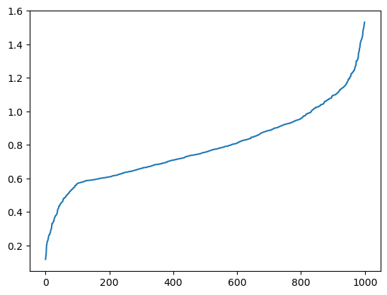

```python
df1_L2sorted.L2.plot.line()
```

```python
df1_nn_ord.head()
```

|  | image_idx | 00 | 01 | 10 | 11 | L2 |
| --- | --- | --- | --- | --- | --- | --- |
| 0 | 758 | 0.999793 | -0.109007 | 0.007793 | 0.044593 | 0.118033 |
| 1 | 50 | 0.999999 | -0.035201 | 0.100799 | 0.084799 | 0.136347 |
| 4 | 42 | 0.999977 | 0.177577 | 0.091177 | 0.063977 | 0.209618 |
| 27 | 524 | 0.999260 | 0.231260 | 0.272860 | 0.008860 | 0.357788 |
| 49 | 730 | 0.999990 | 0.268790 | 0.366390 | -0.017610 | 0.454752 |

```python
# Define a function to update the plot
def init_anim():
  #  fig, axes = plt.subplots(1, 3, figsize=(8,3))
    idx=0
    k=df1_nn_ord.image_idx.iloc[idx]
    myL2=df1_nn_ord.L2.iloc[idx]
    # Update the data for the plot

    # plt.title(get_metrics_compare_regen_images(k))
    occ2d=get_2D_occ_map_from_seq('./image_inputs_seq/ising2D_seq_%s.dat'%str(k).zfill(6))
    axes[0].imshow(np.transpose(occ2d),interpolation='nearest',cmap='gray')
    axes[0].axis("off")
    imdat = read_bin('./image_inputs_bin/hk0_%s.bin'%str(k).zfill(6), npixels=64, offset=1280)
    axes[1].imshow(np.flip(imdat,0),cmap='gray')
    axes[1].axis("off")
    corrf=df1_nn_ord.iloc[idx][1:5].values
    # sns.heatmap(corrf.reshape((2,-1)), ax=axes[2], cmap='bwr', annot=True,square=True,cbar_kws={'shrink':0.75})
    sns.heatmap(corrf.reshape((2,-1)), ax=axes[2], cmap='bwr',square=True, annot=False ,cbar_kws={'shrink':0.75},vmax=1.0,vmin=-1.0  ) #cbar=0 )
  #  for i in range(2):
  #      for j in range(2):
  #          text = axes[2].text(j + 0.5, i + 0.5, "{:.2f}".format(corrf[2*i+j]), ha="center", va="center", color="w")
    # axes[2].set_xlim([0,2])
    # axes[2].set_ylim([0,2])
    # axes[2].set_aspect('equal')
    axes[2].axis('off')
    fig.suptitle("CFS2 vector L2 distance from origin %.3f " %(myL2), fontsize=10, y=0.95)
#    text.remove()
```

```python
# Define a function to update the plot
def plot_image_from_idx(idx):
  #  fig, axes = plt.subplots(1, 3, figsize=(8,3))
    k=df1_nn_ord.image_idx.iloc[idx]
    myL2=df1_nn_ord.L2.iloc[idx]
    # Update the data for the plot

    # plt.title(get_metrics_compare_regen_images(k))
    occ2d=get_2D_occ_map_from_seq('./image_inputs_seq/ising2D_seq_%s.dat'%str(k).zfill(6))
    axes[0].imshow(np.transpose(occ2d),interpolation='nearest',cmap='gray')
    axes[0].axis("off")
    imdat = read_bin('./image_inputs_bin/hk0_%s.bin'%str(k).zfill(6), npixels=64, offset=1280)
    axes[1].imshow(np.flip(imdat,0),cmap='gray')
    axes[1].axis("off")
    corrf=df1_nn_ord.iloc[idx][1:5].values
    # sns.heatmap(corrf.reshape((2,-1)), ax=axes[2], cmap='bwr', annot=True,square=True,cbar_kws={'shrink':0.75})
    sns.heatmap(corrf.reshape((2,-1)), ax=axes[2], cmap='bwr',square=True, cbar=0 ,vmax=1.0,vmin=-1.0  ) #cbar=0 )
    axes[2].axis('off')
    tscale=0.1

    text1.set_text("{:.2f}".format(corrf[2*0+0]))
    text2.set_text("{:.2f}".format(corrf[2*1+0]))
    text3.set_text("{:.2f}".format(corrf[2*0+1]))
    text4.set_text("{:.2f}".format(corrf[2*1+1]))
    # axes[2].set_xlim([0,2])
    # axes[2].set_ylim([0,2])
    # axes[2].set_aspect('equal')


    fig.suptitle("CFS2 vector L2 distance from origin %.3f " %(myL2), fontsize=10, y=0.95)
 #   text.remove()
```

```python
df1_nn_ord
```

[output not shown]

1000 rows × 6 columns

[figure not shown]

```python
# Create an animation object
fig, axes = plt.subplots(1, 3, figsize=(8,3))
mylabels=[]

text1 = axes[2].text(0 + 0.5, 0 + 0.5, '', ha="center", va="center", color="k")
text2 = axes[2].text(0 + 0.5, 1 + 0.5, '', ha="center", va="center", color="k")
text3 = axes[2].text(1 + 0.5, 0 + 0.5, '', ha="center", va="center", color="k")
text4 = axes[2].text(1 + 0.5, 1 + 0.5, '', ha="center", va="center", color="k")


ani = FuncAnimation(fig, plot_image_from_idx, init_func=init_anim(), frames=200, interval=200)

# Display the animation in the notebook

# HTML(ani.to_jshtml())
```

```python
# HTML(ani.to_html5_video())
# this will only work if you have ffmpeg
# just use animated gif for now
```

```python
HTML(ani.to_jshtml())
```

```python
from matplotlib import animation
f = './CFS2_vector_L2_anime.gif'
writergif = animation.PillowWriter(fps=3)
ani.save(f, writer=writergif)
```

```python
from aux_functions import  get_CFS_data_anim
```

```python
df_corfu_cfs3=pd.read_csv('output_correlations_cfs3_5000.csv')
```

```python
list(['image_idx'])+list(df_corfu_cfs3.columns.values[1:])
```

```
['image_idx', '00', '01', '02', '10', '11', '12', '20', '21', '22']
```

```python
def get_NN_ordering(df):
    coord_names=list(df.columns.values[1:])
    df.columns=list(['image_idx'])+list(df.columns.values[1:])
    df.sort_values(coord_names)
    df['L2']=df[coord_names].apply(lambda x: np.linalg.norm(x),axis=1)
    df_L2sorted=df.sort_values('L2').reset_index(drop=True)

    coords=df_L2sorted[ coord_names ].values
    order=get_nearest_nieghbor_ordering(coords,0)

    df_nn_ord=df_L2sorted.loc[order]
    return df_nn_ord
```

```python
df_corfu_cfs3=pd.read_csv('output_correlations_cfs3_5000.csv')
df_nn_ord_cfs3=get_NN_ordering(df_corfu_cfs3)
```

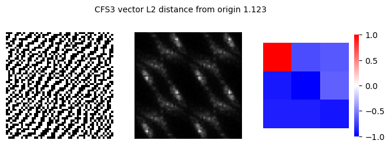

```python
ani2=get_CFS_data_anim(df_nn_ord_cfs3.head(200),seq_dir='./cfs3_image_inputs_seq',bin_dir='cfs3_image_inputs_bin',cfs=3,nframes=200)
```

```python
HTML(ani2.to_jshtml())
```

[figure not shown]

```python
f = './CFS3_vector_L2_anime.gif'
writergif = animation.PillowWriter(fps=3)
ani2.save(f, writer=writergif)
```

```python
df_corfu_cfs4=pd.read_csv('output_correlations_cfs4_5000.csv')
df_nn_ord_cfs4=get_NN_ordering(df_corfu_cfs4)
```

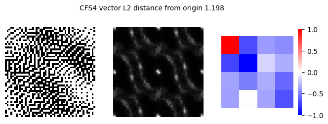

```python
ani3=get_CFS_data_anim(df_nn_ord_cfs4.head(200),seq_dir='./cfs4_image_inputs_seq',bin_dir='cfs4_image_inputs_bin',cfs=4,nframes=200)
```

```python
f = './CFS4_vector_L2_anime.gif'
writergif = animation.PillowWriter(fps=3)
ani3.save(f, writer=writergif)
```

```python
import h5py
# test Open the HDF5 file in read-only mode
with h5py.File('cfs4_big_bin_2.h5', 'r') as f:
    # Get a list of dataset names in the HDF5 file
    dataset_names = list(f.keys())

    # Print the names of all datasets
    for name in dataset_names:
        print(name)
    dset=f[dataset_names[0]]
    X0=dset[:]
```

```
cfs4_big_bin_2
```

```python
np.shape(X0)
```

```
(5, 64, 64)
```

```python
import plotly.express as px
fig = px.imshow(X0, binary_string=True, animation_frame=0, zmax=4)
fig.show()
```

[interactive chart not shown]